Befolkningsutvecklingen i Dalarna

# Befolkningsutvecklingen i Dalarna

Rapporten är skapad av Samhällsanalys, Region Dalarna  
Senast uppdaterad: 2026-05-16

# Sammanfattning

- Dalarnas befolkning minskade med ungefär 500 personer under 2025, en befolkningsminskning som var mindre än året innan. Att befolkningsminskningen har dämpats något år 2025 beror framförallt på att färre personer flyttade från länet än tidigare. Totalt bodde det drygt 286 000 personer i Dalarna vid utgången av år 2025.
- År 2025 uppvisar det lägsta antalet födda barn i Dalarna sen mätningarna började år 1968. Sjunkande födelsetal är en nationell trend men också en trend i de flesta av världens utvecklade länder. De sjunkande födelsetalen planar ut något nationellt men inte i Dalarna.
- Enligt den senaste befolkningsprognosen från Region Dalarna (våren 2025) förväntas den negativa trenden i Dalarnas befolkningsutveckling fortsätta även i framtiden. Befolkningen minskar framförallt i yngre åldersgrupper, medan antalet äldre invånare förväntas öka avsevärt.

# Introduktion

**Ny metod för röjandekontroll**

Från och med referensåret 2025 och framåt har SCB infört en liten kontrollerad slumpmässig osäkerhet (CKM) i befolkningsstatistiken. Osäkerheten har tillförts för att skydda enskilda personer så att ingen riskerar att röjas i statistiken. Till följd av detta så är inte alltid de redovisade totalerna lika med summan av deras redovisade delar. Läs mer om det och annan relevant information i den klickbara rutan information om statistiken nedan eller på SCB:s hemsida.

**Information om statistiken**

Från och med referensåret 2025 och framåt har SCB infört en liten kontrollerad slumpmässig osäkerhet i befolkningsstatistiken. Osäkerheten har tillförts för att skydda enskilda personer så att ingen riskerar att röjas i statistiken. Till följd av detta så är inte alltid de redovisade totalerna lika med summan av deras redovisade delar.

Om redovisade statistikvärden adderas för att skapa en ny total, så adderas även osäkerheten. Det finns därför risk för att den nya totalen innehåller större osäkerhet än vad som, enligt metoden, skulle ha tillförts ett enskilt statistikvärde.

Metoden som används för röjandekontroll heter Cell Key Method (CKM). Du kan läsa mer om metoden här: [Skyddsmetoder för röjandekontroll](https://www.scb.se/dokumentation/statistiska-metoder/skyddsmetoder-for-rojandekontroll/) och här: [utveckling av röjandeskyddet](https://www.scb.se/dokumentation/statistikomraden-under-forandring/utveckling-av-rojandeskyddet/), samt i befolkningsstatistikens dokumentation (kvalitetsdeklarationen, avsnitt 2.2.6).

FAQ om CKM-metoden hittar du här: [Frågor och svar om röjandeskydd i befolkningsstatistiken](https://www.scb.se/FAQ-CKM)

Notera att vissa av diagrammen från en tidigare version av rapporten av denna anledning har tagits bort och kommer eventuellt att publiceras vid ett senare tillfälle.

I folkmängden räknas endast personer som är folkbokförda i landet. För att den som flyttar till Sverige ska bli folkbokförd ska personen ha för avsikt och rätt att stanna i Sverige i minst ett år. För personer som inte är medborgare i ett EU-land innebär det att det krävs ett uppehållstillstånd som gäller minst 12 månader för att bli folkbokförd.

Till följd av Rysslands invasion av Ukraina den 24 februari 2022 har Europeiska unionen (EU) beslutat att aktivera massflyktsdirektivet, vilket innebär att personer från Ukraina utan individuell prövning ska erbjudas tidsbegränsat uppehålls- och arbetstillstånd inom EU. Personer som får uppehållstillstånd enligt massflyktsdirektivet ska i regel inte bli folkbokförda och ingår därmed inte i den officiella befolkningsstatistiken. Läs mer här. Sedan juni 2024 har dock personer födda i Ukraina haft möjlighet att ansöka om att bli folkbokförda i Sverige (SCB).

Under 2023 inledde Skatteverket ett arbete med att granska registret över folkbokförda. Det förde med sig att SCB avregistrerade flera tusen folkbokförda personer som visade sig inte längre bo i Sverige. I folkbokföringen har dessa registrerats som utvandrade till okänt utvandringsland. Läs mer [här](https://www.scb.se/pressmeddelande/sverige-gar-mot-lagsta-befolkningsokningen-pa-manga-ar/).

För en större genomgång av hur folk- och bostadsräkningar går till i Sverige, se SCBs genomgång här.

All data som används i rapporten, förutom befolkningsprognoserna, är offentlig och finns under kategorin befolkning i SCB:s [Statistikdatabas](https://www.statistikdatabasen.scb.se/pxweb/sv/ssd/). Där finns även data för exempelvis befolkningsutvecklingen under 2025 på månadsbasis som publiceras löpande, något som inte behandlas i denna rapport.

Hur folkmängden förändras över tid är en central fråga för såväl samhällsplanering som politik. Befolkningsutvecklingen påverkar allt från bostadsmarknaden och arbetsmarknaden till skatteintäkter och välfärdssystem. Såväl Västvärlden i stort som delar av Asien står inför en rad demografiska utmaningar, såsom en åldrande befolkning och minskande barnafödande. I Sverige var exempelvis barnafödandet per kvinna under 2025 det lägsta som uppmätts.

Under det senaste året har befolkningsutvecklingen förändrats markant och många kommuner som har växt på sistone har nu istället en krympande befolkning. Med utgångspunkt i den typen av trender, analyseras i denna rapport befolkningsutvecklingen i Dalarnas län med fokus på hur folkmängden har förändrats över tid. Genom att undersöka faktorer som födelsetal, dödstal, in- och utvandring, samt flyttmönster, presenteras en bild av de demografiska trenderna i länet. Rapporten ger också en översikt av utvecklingen i länets kommuner.

# 1 Befolkningsutveckling

## 1.1 Folkmängd

För att beskriva befolkningsutvecklingen över längre tidshorisonter används ofta den så kallade demografiska transitionsmodellen. Denna modell beskriver hur befolkningstillväxt och demografiska mönster förändras över tid när ett land utvecklas från ett förindustriellt till ett postindustriellt samhälle. Modellen är vanligtvis indelad i fyra eller fem faser, vilka beskrivs i informationsrutan nedan:

**Den demografiska transitionsmodellen**

- **Steg 1: Förindustriellt stadium.** I det första stadiet har länder höga födelsetal och höga dödstal, vilket resulterar i en stabil men låg befolkningstillväxt. Många barn föds, men många dör också i ung ålder på grund av sjukdomar, dålig medicinsk vård och svält. Detta steg representerar en stor del av mänsklighetens historia fram till 1700-talet.
- **Steg 2: Tidig industrialiseringsstadium.** När medicinsk och hygienisk förbättring sker börjar dödstalen sjunka. Detta leder till en snabb befolkningstillväxt då födelsetalen förblir höga. Många utvecklingsländer befinner sig i detta stadium idag, och historiskt inträffade detta i Europa under 1800-talet.
- **Steg 3: Sen industrialiseringsstadium.** Ekonomisk utveckling, urbanisering och förändrade sociala normer leder till minskande födelsetal. Familjer börjar föredra färre barn på grund av förändrade ekonomiska och sociala förhållanden. Detta stadium kännetecknar Västeuropa och Nordamerika under 1900-talets början.
- **Steg 4: Postindustriellt stadium.** Både födelse- och dödstal stabiliseras på en låg nivå, vilket leder till en långsamt växande eller till och med minskande befolkning. Hög levnadsstandard och god medicinsk vård är kännetecken. Detta gäller för många utvecklade länder idag, inklusive Sverige.
- **Eventuellt Steg 5: Negativ befolkningstillväxt.** I vissa teorier inkluderas ett sista stadium där födelsetalen är så låga att befolkningen minskar, trots låga dödstal. Detta kan leda till en åldrande befolkning med färre unga människor. Några länder i Östeuropa och Japan erfar detta fenomen.

För en djupare genomgång, se exempelvis [Our World in Data](https://ourworldindata.org/demographic-transition).

I Sverige har folkmängden mätts sedan mitten av 1700-talet. Då befann sig Sverige, som hade ungefär 2 miljoner invånare, i ett förindustriellt stadium och präglades i första hand av en agrar ekonomi där befolkningen var beroende av jordbruket för sin försörjning. Under 1800-talet skedde en snabb urbanisering när befolkningen flyttade från landsbygden till städerna. Detta möjliggjordes av den industriella revolutionen som ledde till en ökad efterfrågan på arbetskraft i städerna. I mitten av 1800-talet hade Sveriges befolkning nästintill fördubblats till 3,9 miljoner invånare. Denna utveckling är typisk för det stadium som brukar benämnas tidig industrialisering. Under 1900-talet fortsatte befolkningen att växa och 2017 passerade Sverige 10 miljoner invånare (idag är folkmängden ungefär 10,5 miljoner). Sverige kan sägas befinna sig i ett postindustriellt stadium, där befolkningstillväxten är relativt låg och andelen äldre i befolkningen ökar.

På länsnivå finns data över befolkningen från slutet av 1960-talet. I kartan nedan illustreras utvecklingen av befolkningen i Sveriges län mellan 1968 och 2025 och ett tydligt mönster framgår. Sveriges befolkning har i första hand ökat i de sydliga länen och då framförallt storstadsregioner. I Uppsala län har folkmängden haft den snabbaste utvecklingen med en ökning på ungefär 96 procent sedan 1968. Detta hänger sannolikt samman med den relativa närheten till Stockholm kombinerat med ett av Sveriges främsta lärosäten. Även Hallands och Stockholms län har haft befolkningsökningar på över 70 procent under samma tidsperiod. I de nordligare delarna av landet är bilden annorlunda. Med undantag för Västerbottens län, där befolkningen ökat med ca 19 procent sedan 1968, har befolkningen minskat i de län som utgör Norrland. Störst minskning har skett i Västernorrland, där befolkningen minskat med ca 11 procent under samma tidsperiod. I Dalarna har befolkningen ökat med ungefär 2 procent sedan 60-talet, vilket är högre än näraliggande län som Värmland och Gävleborg men lägre än exempelvis Örebro och Västmanland. Bidragande orsaker till detta är sannolikt avsaknaden av större lärosäten och det relativt långa avståndet till storstadsregioner som Stockholm.

[interactive chart not shown]

På kommunnivå i Dalarna framträder ett liknande mönster, men i mindre skala. Befolkningen har ökat mest i Falun, där den ökat med ungefär 31 procent sedan 1968. Även i Borlänge och näraliggande pendlingsorter som Säter och Gagnef har befolkningen ökat tydligt. Därutöver har befolkningen ökat mest i Leksand och Mora. Dessa ökningar har skett på bekostnad av framförallt mindre kommuner i norra och västra Dalarna, där exempelvis Älvdalen och Vansbro har haft en befolkningsminskning på närmare 30 procent sedan 1968. I de södra delarna av länet är det framförallt tidigare bruksorter som Avesta och Ludvika som haft en större befolkningsminskning (strax över 20 procent).

[interactive chart not shown]

Sammantaget har Dalarnas befolkning ökat från 278 996 personer år 1968 till 286 043 personer år 2025. Som störst var befolkningen i Dalarna 1994, då den uppgick till 291 203 personer.

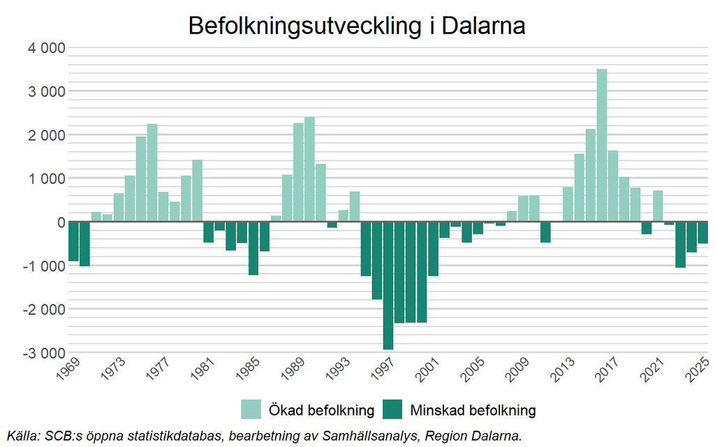

## 1.2 Åldersstruktur

*Notera att diagrammet nedan inte har uppdaterats med ny data. Detta sker eventuellt vid ett senare tillfälle.*

Även om folkmängden i Dalarna idag är ungefär lika stor som den var i slutet av 1960-talet, är dess sammansättning väsentligt annorlunda, framförallt när det kommer till åldersfördelningen. Från slutet av andra världskriget fram till mitten av 1960-talet föddes många barn i Sverige, vilka brukar sägas tillhöra generationen “baby-boomers”. Detta syns tydligt i diagrammet nedan, där andelen av befolkningen som var under 30 år 1968 var klart högre än idag. I början av 1990-talet fick många “baby-boomers” barn. Dessa är idag är runt 30 år gamla. Till följd av detta är personer i den åldersgruppen klart fler idag än de var på 1960-talet. I diagrammet framgår även att andelen av befolkningen som är 65 år eller äldre har ökat kraftigt sedan 1968. Detta hänger samman med att “baby-boomers” börjar nå pensionsåldern, samtidigt som den förväntade livslängden i samhället stadigt ökat över tid.

[figure not shown]

I fortsättningen av denna rapport delas Dalarnas befolkningsutveckling in i de mest centrala komponenterna; födelsenetto, dvs. nettot av födda och döda, samt flyttnetto, dvs. nettot av inrikes och utrikes flyttar.

# 2 Födelsenetto

## 2.1 Fruktsamhet

Summerad fruktsamhet per kvinna är ett mått på hur många barn som en kvinna i genomsnitt skulle föda under sin fruktsamma period utifrån, den vid tidpunkten för beräkningen, gällande fruktsamheten. I relation till befolkningen var barnafödandet i Sverige år 2025 det lägsta som uppmätts (SCB har data sedan mitten av 1700-talet), en utveckling som är densamma i stora delar av västvärlden (SCB). Skillnaden jämfört med 2024 var dock liten. En viktig förklaring till att barnafödandet har minskat i Sverige under 2010-talet är att sannolikheten att skaffa sitt första barn har minskat. För en fördjupad diskussion runt det låga barnafödandet i Sverige, se informationsrutan nedan.

**Ett historiskt lågt barnafödande**

Forskare vid Stockholms universitet [(Ohlsson-Wijk & Andersson, 2022)](https://www.demographic-research.org/articles/volume/47/12) har analyserat utvecklingen under 2010-talet och konstaterar att det som främst driver nedgången i antal födslar är en minskad sannolikhet att skaffa sitt första barn. Det sker en kraftig nedgång från tidigt 90-tal fram till millennieskiftet, en svag uppgång fram till finanskrisen 2008 och därefter en fortsatt nedgång från 2010 och framåt. Givet att en familj har skaffat ett första barn är däremot sannolikheten att skaffa ett andra barn inte påverkad i samma omfattning. Sannolikheten att skaffa ett tredje eller fjärde barn är i princip opåverkade från millennieskiftet och framåt, men på låga nivåer och har begränsad påverkan på födelsetalen. Det sker samtidigt en förskjutning i kvinnors ålder för födsel av det första barnet, vilket sammantaget innebär att färre skaffar barn, de som skaffar barn gör det senare och färre får flera barn (SCB, 2024). Färre födda barn ger i förlängningen även färre kvinnor i barnafödande åldrar i framtiden, vilket bidrar till den långsiktiga utmaningen.

För att se om den här utvecklingen drivs av särskilda grupper i samhället studerar [(Ohlsson-Wijk & Andersson, 2022)](https://www.demographic-research.org/articles/volume/47/12) nedgången i relation till individers geografiska hemvist, ursprung, arbetsmarknadsstatus samt inkomster. Det visar sig att det är en i stort sett homogen utveckling över olika samhällsgrupper. Undantaget finns i den grupp som har en svag position på arbetsmarknaden, med låg utbildning och låga inkomster. Där är den negativa utvecklingen som starkast. Det som överraskar forskarna är att nedgången under 2010-talet sker under en period av ekonomisk uppgång, vilket tidigare har varit en stark drivkraft för ökat barnafödande. Av den anledningen har efterföljande forskning riktat in sig på att identifiera andra drivkrafter till nedgången.

[Neyer et al (2022)](https://su.figshare.com/articles/preprint/Fertility_Decline_Fertility_Reversal_and_Changing_Childbearing_Considerations_in_Sweden_A_turn_to_subjective_imaginations_/19698442?file=36144144) studerar nedgången i barnafödande med hjälp av data från den svenska Generations and Gender Survey 2021. Det som är tydligt är att beslut om att skaffa barn eller inte, i allt mindre grad drivs av observerbara och konkreta förhållanden som påverkar individen, till exempel makroekonomiska upp- och nedgångar eller policyförändringar i välfärdssystemet. Den nuvarande trenden utmanar därmed traditionella demografiska förklaringsmodeller och utvecklingen kan observeras i ett stort antal länder i västvärlden med skilda samhälls-, arbetsmarknads- välfärds- och familjeförutsättningar.

Förklaringen till den nedgång i benägenheten att skaffa barn som nu kan observeras är snarare att individer i större grad väger in en upplevd oro och osäkerhet om globala faktorer i framtiden som ligger bortom individens kontroll. Forskarna beskriver det här som en ”subjektiv vändning” kring beslutsfattandet, vilket riskerar att göra det svårare att bedöma utvecklingen av barnafödandet i framtiden.

Utöver den forskning som analyserar utvecklingen under 2010-talet är det noterbart att nedgången fortsatt även början på 2020-talet, i en takt som tidigare inte observerats. År 2023 föddes drygt 100 000 barn i Sverige, vilket var det lägsta antalet på 20 år. Det summerade fruktsamhetstalet, som anger genomsnittligt antal barn per kvinna, sjönk under samma år till 1,45 – den lägsta nivån som någonsin uppmätts i landet [(SCB, 2024)](https://www.scb.se/contentassets/548afb898d0a46419ec6f01189811cc2/be0401_2024i70_br_be51br2401.pdf). Denna nedåtgående trend har fortsatt in i 2024, med färre födslar jämfört med motsvarande perioder tidigare år. Preliminära siffror för 2024 indikerar att antalet födslar understiger 2023 års nivå. Samtidigt har medelåldern för förstagångsföräldrar stigit till rekordhöga nivåer, vilket indikerar att många väljer att skaffa barn senare i livet. SCB:s bedömning av fruktsamhetstalets utveckling framöver är att det kommer att stiga till drygt 1,7 i mitten av 2030-talet, men att det är svårt att förutspå upp- och nedgångar på längre sikt.

SCB visar utvecklingen över tid i den senaste befolkningsframskrivningen [(SCB, 2024)](https://www.scb.se/contentassets/548afb898d0a46419ec6f01189811cc2/be0401_2024i70_br_be51br2401.pdf) genom att beräkna andelen kvinnor, födda i Sverige som fått minst ett barn efter ålder och födelseår. Diagram 4.2 visar att andelen kvinnor som förväntas ha fött minst ett barn vid 45 års ålder minskar över tid.

Av kvinnor födda på 50-, 60- och 70-talet hade cirka 85 procent minst ett barn vid 45 års ålder. Den andelen förväntas sjunka några procentenheter för kvinnor födda på mitten av 80-talet och framåt. Dessutom visar diagrammet tydligt den utveckling som sker i att allt fler skaffar barn i högre åldrar, det vill säga en senareläggning av barnafödandet. 50 procent av kvinnor födda 1960 hade minst ett barn vid 27 års ålder. För kvinnor födda 2000 antas denna ålder ha ökat till 32 år.

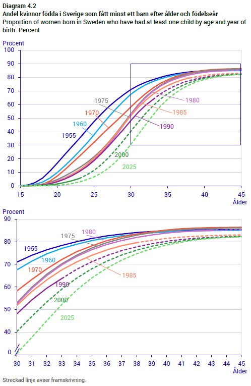

[SKR (2024)](https://skr.se/skr/ekonomijuridik/ekonomi/ekonomirapporten.46417.html) bedömer att det kommer att dröja en bit in på 2040-talet innan antalet 0-åringar når upp till 2020 års nivå. Den utveckling som nu pågår får stor påverkan på kommunernas förskole- och skolverksamhet de kommande decennierna. [(SCB, 2024)](https://www.scb.se/contentassets/548afb898d0a46419ec6f01189811cc2/be0401_2024i70_br_be51br2401.pdf) visualiserar denna utveckling historiskt och även framåt i ett antal diagram (3.1, 3.2 och 3.4) över 0-åringar, 1-5-åringar respektive 6-15-åringar. Hösten 2022 var knappt 509 000 barn inskrivna i förskolan i Sverige. Det minskade barnafödandet de senaste åren leder till att denna siffra minskar med 85 000 barn i slutet av 2020-talet.

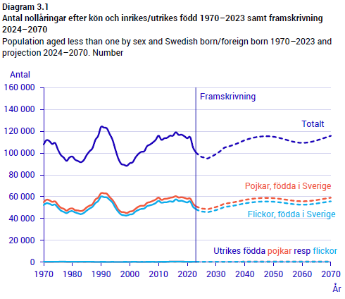

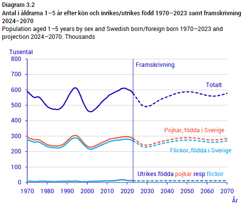

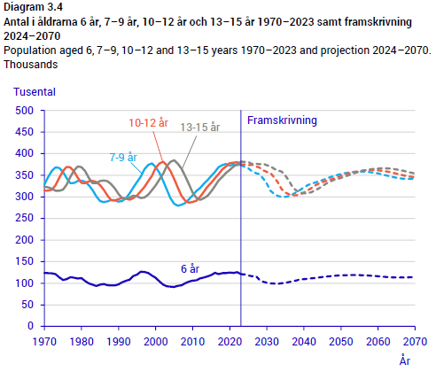

Fruktsamheten i Dalarna följer i praktiken samma mönster som fruktsamheten i Sverige, men är något högre. Bland Dalarnas kommuner hade Säter år 2025 den högsta fruktsamheten (ungefär 1,8), medan Malung-Sälen hade den lägsta (knappt 1). Som jämförelse var fruktsamheten i Dalarna knappt 1,5 år 2025 och fruktsamheten i Sverige drygt 1,4.

Det är dock viktigt att notera att fruktsamheten på kommunnivå kan variera relativt mycket över tid. I större kommuner som Falun och Borlänge påminner utvecklingen om den i Dalarna och Sverige, där fruktsamheten ser ut att följa en trend. I mindre kommuner är variationen större mellan åren och det blir svårare att utläsa en långsiktig trend. Ett tydligt exempel på det är Gagnef som 2023 hade den högsta fruktsamheten bland länets kommuner, men året efter hade bland de lägsta. År 2025 var fruktsamheten i Gagnef återigen bland länets högsta (dock inte på samma nivå som 2023).

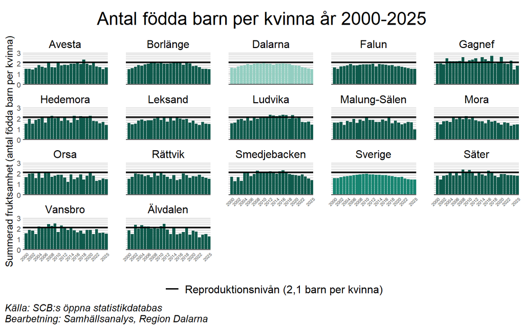

## 2.2 Nettot mellan födda och döda

Under 2025 avled knappt 3 100 personer boende i Dalarna, vilket var något färre än året innan. Generellt går utvecklingen i länet mot att människor lever allt längre. I slutet av 1960-talet dog runt 3 300 personer i Dalarna, vilket är fler än idag, trots att befolkningen då hade en annan ålderstruktur med en betydligt större andel unga (se avsnittet om åldersstruktur ovan). En viktig förklaring till detta är att den förväntade livslängden ökat kraftigt över tid, från 72 år för män och 77 år för kvinnor år 1970 till ungefär 82 år för män och 85 år för kvinnor idag ([SCB](https://www.scb.se/hitta-statistik/sverige-i-siffror/manniskorna-i-sverige/medellivslangd-i-sverige/#Medellivslangd_over_tid)). För en diskussion runt varför medellivslängden i Sverige har ökat över tid, se exempelvis [KI](https://ki.se/forskning/popularvetenskap-och-dialog/popularvetenskapliga-teman/tema-halsosamt-aldrande/nyfiken-pa-livslangd) eller [SCB](https://www.scb.se/hitta-statistik/sverige-i-siffror/manniskorna-i-sverige/medellivslangd-i-sverige).

Även när det gäller antalet födslar är trenden negativ. Under vissa år i början av 1990-talet föddes över 4 000 barn i Dalarna, men därefter skedde en dramatisk nedgång, vilket sannolikt hör samman med 1990-talskrisen (se även avsnittet om fruktsamhet ovan). Under 2000-talet skedde en gradvis ökning av antalet födda fram till åren runt 2016 när många invandrade till Dalarna. Därefter har födslarna återigen börjat minska och år 2025 föddes knappt 2 200 barn i Dalarna, den lägsta siffran sedan åtminstone 1968.

Sammantaget har nettot mellan födda och döda, se de svarta linjerna i diagrammet nedan, varit negativt i Dalarna under varje år sedan början av 1990-talet. Hur många invånare som länet tappar på grund av det varierar relativt mycket mellan åren.

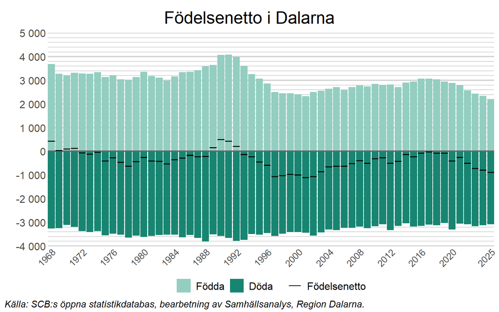

# 3 Flyttnetto

Som föregående diagram visade, bidrar nettot mellan födda och döda i praktiken alltid negativt till Dalarnas befolkningsutveckling. För att Dalarnas folkmängd skall växa blir det därför helt centralt att fler flyttar till länet än de som flyttar därifrån. Flyttarna till och från Dalarna kan delas upp i två delar:

- **Inrikes flyttar**, dvs. de som flyttar till och från länet från andra delar av Sverige.
- **Utrikes flyttar**, dvs de som flyttar till och från länet från andra delar av världen (in- och utvandring).

## 3.1 Inrikes flyttningar

Generellt flyttar personer inrikes i första hand till större städer och universitetsorter. Detta hänger sannolikt samman med att dessa orter har en stor arbetsmarknad och goda utbildningsmöjligheter.

Bland Sveriges län sticker Skåne ut, med mer än dubbelt så stort inrikes flyttnetto som något annat län. Även Uppsala sticker ut, med stort flyttnetto relativt sin befolkning. Anmärkningsvärt är även att inrikes flyttnettot till Stockholms län var negativt under 2025, vilket är i linje med en trend de senaste åren. En viktig förklaring till det är sannolikt att den stora gruppen födda i början av 1990-talet börjar komma upp i 30-årsåldern och då väljer att flytta från Stockholm till mindre städer. Störst negativt inrikes flyttnetto hade Västerbottens län, vilket hänger samman med konkursen för batteritillverkaren Northvolt i Skellefteå, något som lett till en stor utflyttning.

I Dalarna var det inrikes flyttnettot under 2025 negativt och 6:e lägst bland Sveriges län.

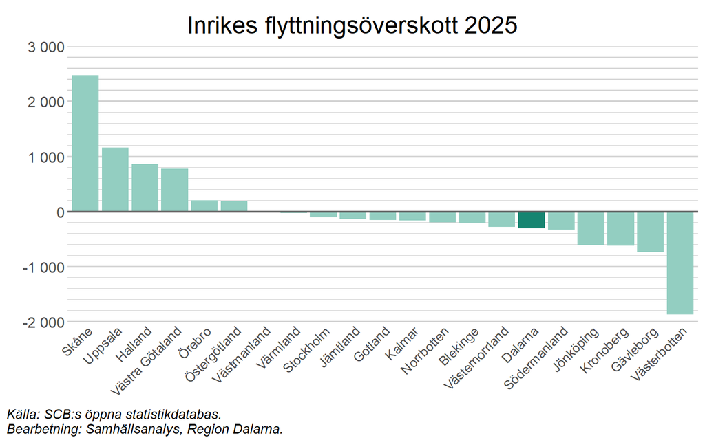

Att det inrikes flyttnetto i Dalarna var negativt under 2025 är inget unikt. Sedan slutet av 1990-talet har det varit negativt i Dalarna under en överväldigande majoritet av åren. En viktig förklaring till detta är sannolikt att befolkningen i Sverige blir mer urbaniserad, vilket innebär att allt fler flyttar från mindre län till storstadsregioner. I Dalarna är det framförallt unga personer som flyttar, vilket kan förklaras med att de flyttar för att studera och arbeta. Mer om detta senare.

Intressant att notera är dock att det inrikes flyttnettot i Dalarna under 2025 var tydligt mindre negativt, jämfört med åren innan.

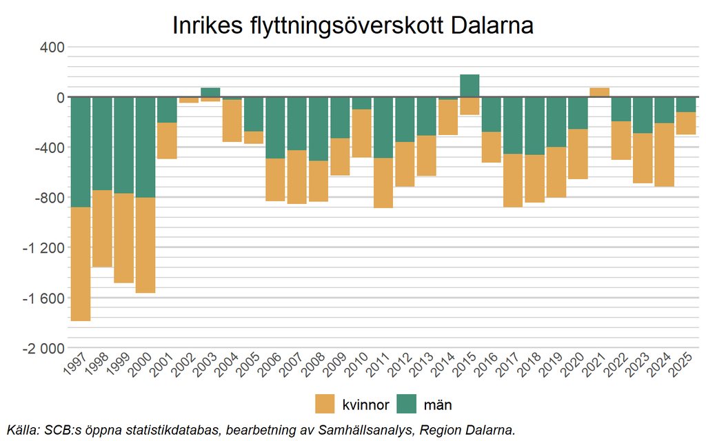

*Notera att de två diagrammen nedan inte har uppdaterats med ny data. Detta sker vid ett senare tillfälle.*

Flyttar från Dalarna inrikes sker i första hand till antingen större eller näraliggande län. Flest flyttar skedde till Stockholm, följt av Västmanland och Uppsala. Få flyttar till små län långt bort, såsom Gotland och Blekinge.

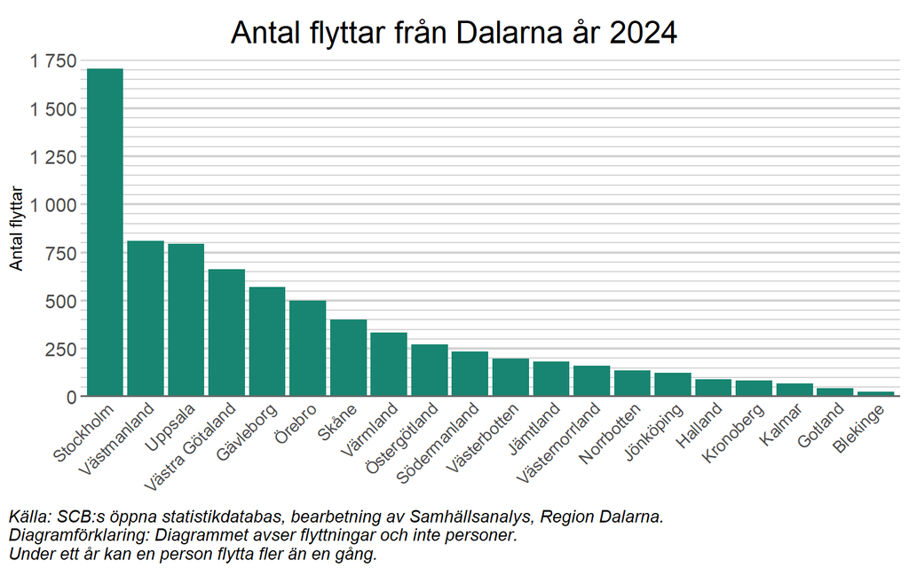

Inrikes flyttningar till Dalarna följer ett liknande mönster. Flest flyttar till Dalarna från Stockholm, Uppsala och Västmanland. Generellt går något fler flyttar från än till Dalarna, vilket är i linje med att länet har ett negativt flyttnetto inrikes. Ett undantag är Stockholm, då antalet flyttar från Dalarna till Stockholm var färre än antalet flyttar till Dalarna från Stockholm år 2024.

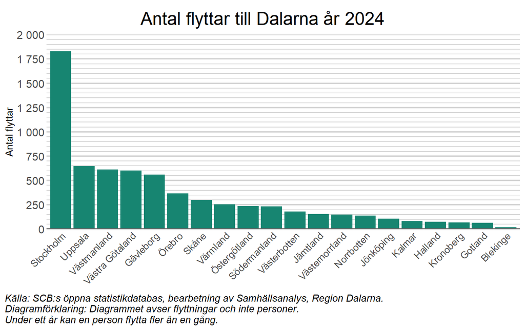

## 3.2 Utrikes flyttningar

Viktigt att notera är även att det anmärkningsvärt låga nettot 2023, jämfört med åren innan, delvis kan förklaras med att Skatteverket under 2023 inledde ett arbete med att avregistrera tusentals folkbokförda personer som vid en granskning visat sig inte längre bo i Sverige (se informationsrutan under avsnittet introduktion ovan). Totalt avskrevs drygt 190 personer i Dalarna som utvandrade 2023 och ungefär 260 personer 2024.

Den främsta anledningen till det låga invandringsöverskottet på senare år är dock sannolikt en förändrad migrationspolitik. Med undantag för 2024, invandrade mellan 1 400 och 1 800 personer till Dalarna årligen under perioden 2020-2023 samt 2025, att jämföra med mellan 2 000 och 3 000 personer årligen åren dessförinnan.

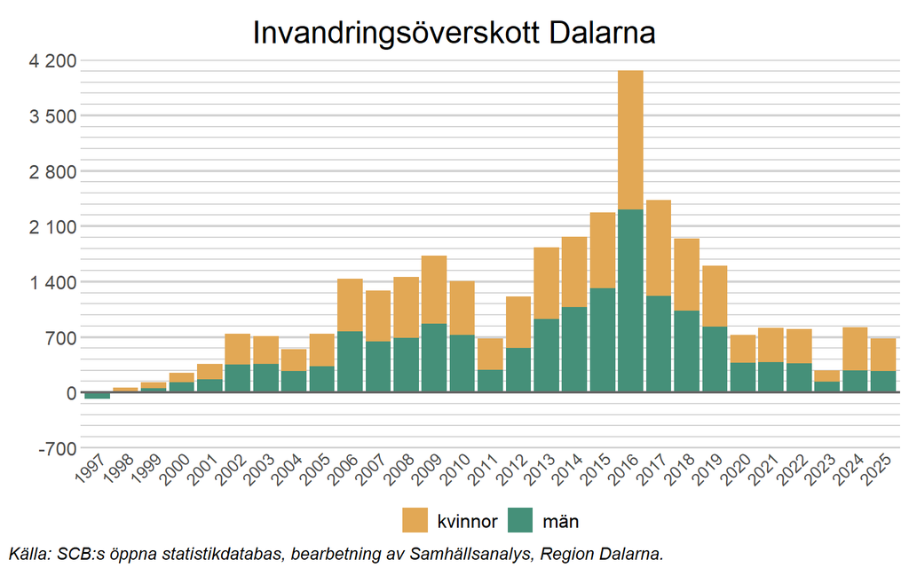

## 3.3 Flyttnetto

Sammantaget har Dalarnas län haft ett positivt flyttnetto under de flesta åren sedan millennieskiftet, vilket förklarar varför befolkningen har ökat. Efter att ha ökat marginellt under 2024, var flyttnettot till Dalarna tydligt mer positivt 2025. Att flyttnettot blev mer positivt under 2025 beror på att det inrikes flyttnettot var mindre negativt, vilket diskuterades i avsnittet “inrikes flyttningar” ovan.

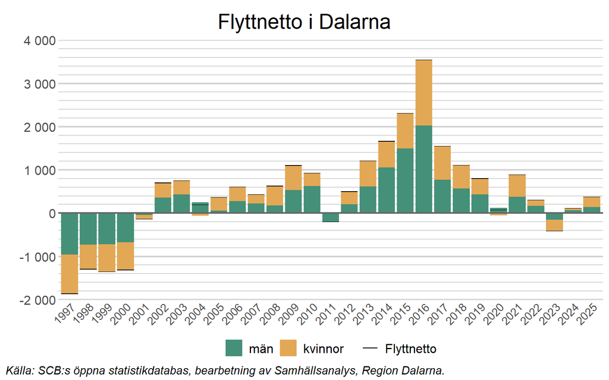

I nästa avsnitt är fokus istället på framtiden. Hur kommer Dalarnas folkmängd att utvecklas fram till år 2034?

# 4 Vad händer i framtiden?

*Notera att prognosen nedan gjordes våren 2025. Avsnittet kommer därför att uppdateras med en ny prognos under våren 2026.*

Till följd av att SCB bara gör befolkningsprognoser vart tredje år på läns- och kommunal nivå, har Region Dalarna, med hjälp av ett skript i R som Region Halland skapat, valt att ta fram egna befolkningsprognoser. Eftersom prognoser blir osäkrare desto längre fram i tiden de sträcker sig, är fokus i detta avsnitt enbart på prognosen 10 år framåt i tiden, dvs. fram till 2034. För SCB:s senaste befolkningsprognos för Dalarna, se [SCB, 2024](https://www.statistikdatabasen.scb.se/pxweb/sv/ssd/START__BE__BE0401__BE0401A/BefProgRegFakN/).

För en djupare förståelse för hur Region Dalarna gör sina befolkningsprognoser, se informationsrutan nedan. Till skillnad från de prognoser som SCB gör, har Region Dalarna valt att ta hänsyn till Ludvikas expansion kopplat till Hitachi i sina befolkningsprognoser. Detta påverkar även prognos för hela Dalarna. För övriga kommuner, tas ingen hänsyn i prognoserna till exempelvis företagsetableringar eller andra framtida mål och förutsättningar som kommunerna har i sina planer. Metoden är i övrigt till stora delar densamma som SCB använder.

**Region Dalarnas Befolkningsprognoser**

Den framtida befolkningens storlek och sammansättning bestäms av antaganden om den framtida utvecklingen av fruktsamhet, dödlighet och flyttningsmönster. Beräkningarna bygger på vad som observerats under de senaste åren och ett antagande om att den utvecklingen fortsätter. I beräkningarna tas ingen hänsyn till exempelvis företagsetableringar eller andra framtida mål och förutsättningar i kommunerna.

Både små och stora strukturförändringar i samhället påverkar den framtida befolkningsutvecklingen, vilket innebär att det finns en osäkerhet förenad med framskrivningen. Notera att befolkningsframskrivningen endast ger en uppskattning av hur en framtida befolkning kan komma att se ut. Generellt gäller att osäkerheten i framskrivningen ökar med åren.

Befolkningsprognoser visar hur utvecklingen kommer att bli om den fortsätter ungefär som nu, alltså att fruktsamhet, dödlighet, flyttar samt invandring/utvandring fortsätter som tidigare i varje 1-årsgrupp per kön.

I diagrammet nedan visas befolkningsutvecklingen i Dalarna fram till 2034 uppdelat på åldersgrupper.

- Folkmängden i Dalarna prognostiseras att minska till 280 000 personer år 2034, en minskning med ungefär 6 500 personer jämfört med 2024. Även i SCB:s senaste prognos (juni 2024), prognostiserades en befolkning på ungefär 280 000 personer i Dalarna år 2034 (se [SCB, 2024](https://www.statistikdatabasen.scb.se/pxweb/sv/ssd/START__BE__BE0401__BE0401A/BefProgRegFakN/)).
- Den största minskningen sker i åldersgruppen 0-19 år, som prognostiseras att minska med knappt 8 400 personer. Detta kan sannolikt delvis förklaras av att fruktsamheten minskat de senaste åren.
- I åldergruppen 80+ förväntas befolkning att öka med ungefär 6 400 personer fram till 2034. Detta hänger sannolikt samman med att den förväntade livslängden fortsätter öka och att den stora gruppen “baby-boomers” börjar komma upp i 80-års åldern.
- Även antalet personer i åldersgrupp som brukar benämnas arbetsför ålder, 20-65 år, förväntas minska tydligt fram till 2034.

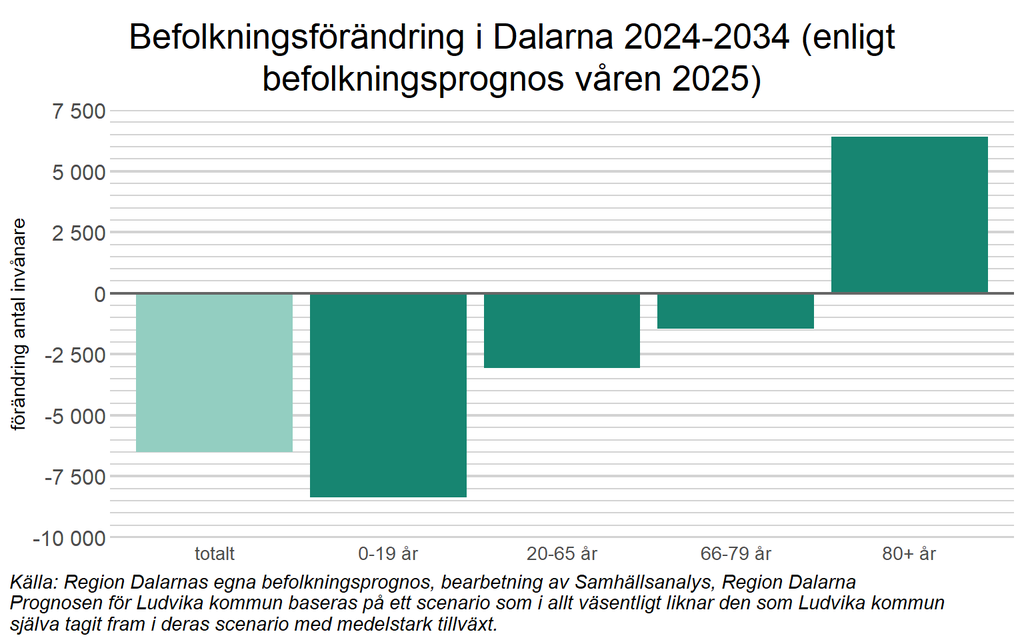

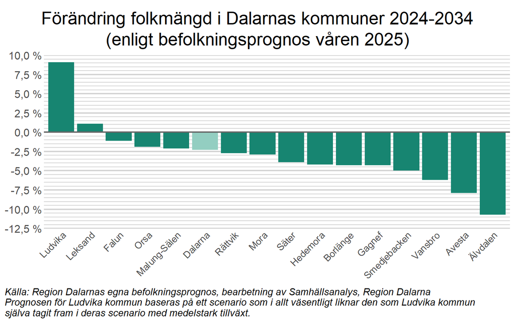

# 5 Kommunfördjupningar

*På grund av att SCB infört en ny röjandekontrollsmetod (CKM) kommer kommunfördjupningarna att fördröjas och publiceras vid ett senare tillfälle. Läs mer om CKM i avsnittet introduktion*.